# Exercise 10: Adjusting for a batch/technical effect + differential exon usage

Martin Holub

15/11/2017

In the first part of this exercise, we will revisit the analysis from Exercise 8 (pasilla dataset), to account for a covariate. In the second part, we will use (preprocessed) exon-level counts to look for changes in splicing.

```r
samples <- read.table("data/samples.txt", header=TRUE,
                      row.names=5, stringsAsFactors=FALSE)
counts <- edgeR::readDGE(samples$countfile, path = "data/")$counts
# remove some rows that are not features
counts <- counts[ grep("^FBgn",rownames(counts)), ]

grp <- gsub("\\-.[0-9]*","",colnames(counts))
grp
```

```
## [1] "CG8144_RNAi" "CG8144_RNAi" "CG8144_RNAi" "Untreated"   "Untreated"
## [6] "Untreated"   "Untreated"
```

#### Exercise 1. Take the data from Exercise 8 and produce an MDS plot again, but this time colour the points according to the covariate in the samples table: libtype (SE = single end, PE = paired end); perhaps also label the points on the MDS plot using the ‘shortname’ column to make them easy to distinguish. Comment on the organization of the samples.

#### Answer 1.:

In the MDS plot we observe clustering of samples based on 1) treatement (or absence thereof) and 2) library type (SE = single end, PE = paired end). In the following code we will look at what does the difference between paired and single end reads stem from in temrs of available data.

```r
group <- factor(grp)
y <- edgeR::DGEList(counts=counts, group=group)
y <- edgeR::calcNormFactors(y, method = "TMM") # adjust for different sizes of libraries
design <- model.matrix(~group)
y <- edgeR::estimateDisp(y,design) # estimate common, trended and tagwise dispersion
# Perform likelihood ratio tests:
fit <- edgeR::glmFit(y,design)
lrt <- edgeR::glmLRT(fit,coef=2) # DGELRT-class
edgeR::topTags(lrt) # OK, same as in EX8
```

```
## Coefficient:  groupUntreated
##                 logFC   logCPM       LR        PValue           FDR
## FBgn0039155  4.612741 5.845070 544.2396 2.254932e-120 3.432232e-116
## FBgn0025111 -2.931592 6.846509 299.6081  4.010169e-67  3.051939e-63
## FBgn0039827  4.026055 4.375892 297.0349  1.458055e-66  7.397685e-63
## FBgn0034736  3.532058 4.117224 226.6718  3.170993e-51  1.206642e-47
## FBgn0003360  3.171063 8.402099 211.6352  6.041002e-48  1.839002e-44
## FBgn0035085  2.526337 5.560392 206.4917  8.004149e-47  2.030519e-43
## FBgn0000071 -2.715678 4.708844 197.5750  7.063882e-45  1.535991e-41
## FBgn0029167  2.200684 8.156496 192.5657  8.756257e-44  1.665987e-40
## FBgn0029896  2.408030 5.222842 179.1951  7.263678e-41  1.228449e-37
## FBgn0034434  3.530262 3.138099 168.1657  1.861252e-38  2.833012e-35
```

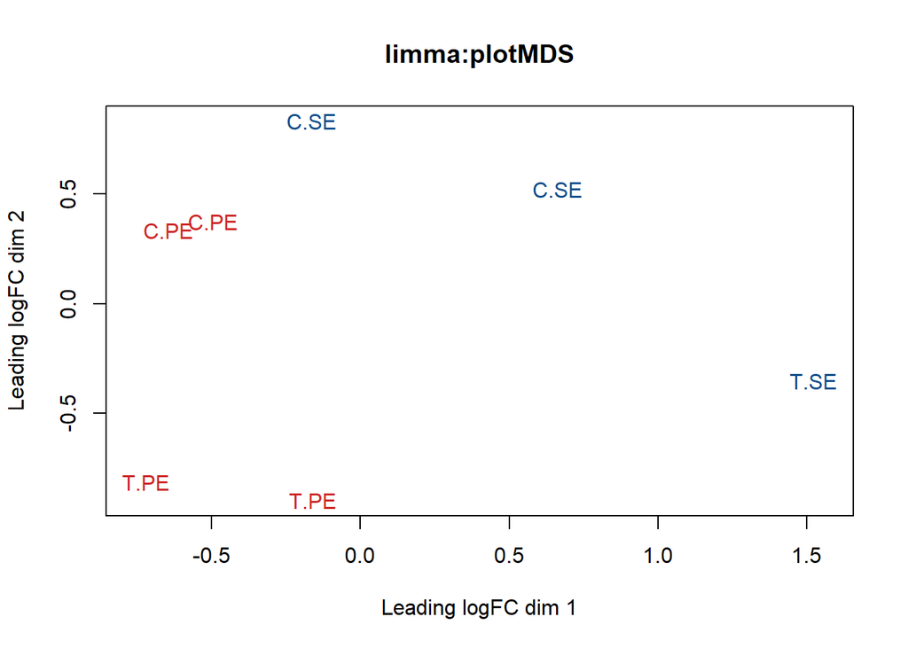

```r
# Prepare colors
farbs <- rep('firebrick3', length(samples$libtype))
farbs[samples$libtype == 'SE'] <- 'dodgerblue4'

# Prepare annotation C/T and SE/PE
conds <- rep('C.', length(samples$condition))
conds[samples$condition == "T"] <- "T."
conds <- paste0(conds, samples$libtype)

limma::plotMDS(y, labels =  conds, col = farbs, main = "limma:plotMDS")
```

#### Exercise 2. Put a factor variable for the ‘libtype’ covariate in the design matrix and redo the edgeR or limma analysis from Exercise 8 (i.e., include also the biological factor, knockout state, in the design matrix). Compare the set of genes called DE from last week’s exercise (i.e., without accounting for the covariate) to this new analysis. Identify and plot (normalized) expression levels of a gene that is affected solely by library type.

#### Answer2:

- I am unclear on `include also the biological factor, knockout state`, but from the previous I understand it as refining the groups by including information on whether the data was acquired as SE or PE. *

Morover, I came up with multiple ways how to define the contrasts and it feels that multiple are applicable in this case. In this script, I do the analysis twice. Once to check for differences between SE/PE respecting C/T difference and second the same way as before (Exercise8), to see differences just between C/T. I then look for genes that are differentially expressed in the first case but not found in the second scenario.

```r
conds <- factor(conds)
design <- model.matrix(~ 0 + conds)
colnames(design) <- levels(conds)
design
```

```
##   C.PE C.SE T.PE T.SE
## 1    0    0    0    1
## 2    0    0    1    0
## 3    0    0    1    0
## 4    0    1    0    0
## 5    0    1    0    0
## 6    1    0    0    0
## 7    1    0    0    0
## attr(,"assign")
## [1] 1 1 1 1
## attr(,"contrasts")
## attr(,"contrasts")$conds
## [1] "contr.treatment"
```

```r
# libtype <- factor(samples$libtype)
# design <- model.matrix(~ 0 + libtype)
# colnames(design) <- levels(libtype)
# design

cont.matrix <- limma::makeContrasts( # Multiple ways how to define conttrasts
                                    #CP_SE="C.PE-C.SE",
                                    CSE_TPE = "C.SE-T.PE",
                                    CPE_TSE = "C.PE-T.SE",
                                    CSE_TSE = "C.SE-T.SE",
                                    CPE_TPE = "C.PE-T.PE",
                                    #TP_SE="T.PE-T.SE",
                                    #PE_SE="(C.PE+T.PE)-(C.SE+T.SE)",
                                    #C_T  = "(C.PE+C.SE)-(T.PE+T.SE)",
                                    #PE_SE = "PE-SE",
                                    levels=design)
cont.matrix
```

```
##       Contrasts
## Levels CSE_TPE CPE_TSE CSE_TSE CPE_TPE
##   C.PE       0       1       0       1
##   C.SE       1       0       1       0
##   T.PE      -1       0       0      -1
##   T.SE       0      -1      -1       0
```

```r
## Build also matrix just for comparison between C and T
group <- factor(samples$condition)

design2 <- model.matrix(~ 0 + group)
colnames(design2) <- levels(group)
design2
```

```
##   C T
## 1 0 1
## 2 0 1
## 3 0 1
## 4 1 0
## 5 1 0
## 6 1 0
## 7 1 0
## attr(,"assign")
## [1] 1 1
## attr(,"contrasts")
## attr(,"contrasts")$group
## [1] "contr.treatment"
```

```r
cont.matrix2 <- limma::makeContrasts(C_T  = "C-T",levels=design2)
cont.matrix2
```

```
##       Contrasts
## Levels C_T
##      C   1
##      T  -1
```

```r
y <- edgeR::DGEList(counts=counts, group=group)
y <- edgeR::calcNormFactors(y, method = "TMM") # adjust for different sizes of libraries

y <- edgeR::estimateDisp(y,design) # estimate common, trended and tagwise dispersion
fit <- edgeR::glmFit(y,design)
lrt <- edgeR::glmLRT(fit, contrast = cont.matrix) # DGELRT-class
DE_genes <- edgeR::topTags(lrt, n = Inf, adjust.method = "BH", p.value = 0.01)# Take all genes with p < threshold
head(DE_genes)
```

```
## $table
##             logFC.CSE_TPE logFC.CPE_TSE logFC.CSE_TSE logFC.CPE_TPE
## FBgn0039155  4.5742833987   4.729486608  4.8925711670  4.4111988398
## FBgn0025111 -3.1526068005  -2.556652552 -2.7527703498 -2.9564890028
## FBgn0039827  3.8583974290   4.224424151  4.0156535441  4.0671680362
## FBgn0003360  3.3921452428   2.903421149  3.3617888998  2.9337774919
## FBgn0000071 -2.9957736451  -2.338245583 -2.7553750290 -2.5786441989
## FBgn0035085  2.3303287255   2.818995230  2.6363698292  2.5129541260
## FBgn0034736  3.2719062899   3.902736983  3.6761319795  3.4985112929
## FBgn0013680  2.1912768561  -6.085260430 -3.1638478349 -0.7301357391
## FBgn0029896  2.4203628046   2.350374712  2.2338403370  2.5368971794
## FBgn0029167  2.2113560096   2.174200658  2.1611543228  2.2244023446
## FBgn0034434  3.4613436545   3.577957430  3.3225654322  3.7167356518
## FBgn0011260 -1.9183936877  -2.674271432 -2.4614850633 -2.1311800566
## FBgn0013688  1.6939629216  -6.128383054 -4.5901751185  0.1557549864
## FBgn0051092 -2.3120333303  -2.321854545 -2.1927916192 -2.4410962565
## FBgn0026562  1.7645420420   3.116047269  2.4378798954  2.4427094156
## FBgn0037754  2.8214283552   1.693052657  2.3356859776  2.1787950348
## FBgn0038832  2.8173089182   2.412604471  2.8651068093  2.3648065801
## FBgn0013679  3.4758939004  -5.571137706 -1.7781052378 -0.3171385680
## FBgn0261673 -3.2271127039  -3.502768254 -3.4289846107 -3.3008963470
## FBgn0035189 -3.3992489941  -2.519230638 -2.9685159157 -2.9499637163
## FBgn0085359  5.7108920352   3.712727124  4.2580277327  5.1655914261
## FBgn0040099  2.0514145142   1.297296331  1.3755405850  1.9731702607
## FBgn0024288  3.8749433255   5.432422796  5.0862375653  4.2211285560
## FBgn0262733 -1.9278860126  -2.361056069 -2.2746742575 -2.0142678245
## FBgn0052407  2.3467099574   1.816166285  1.9322414036  2.2306348384
## FBgn0013675  1.3603189205  -2.321051592 -0.9598521208 -0.0008805506
## FBgn0085818  4.5370770742  -6.802966131 -2.4157864438  0.1498973874
## FBgn0031150 -0.8753443386  -1.720888655 -1.3857319429 -1.2105010506
## FBgn0002868  2.8464082317   1.572101091  2.4862979782  1.9322113443
## FBgn0034897  1.8154819697   1.986119694  1.7136348268  2.0879668365
## FBgn0032405 -2.4856260845  -2.597941151 -2.6031545958 -2.4804126401
## FBgn0040827  2.2079155082   1.634548106  1.8158128626  2.0266507519
## FBgn0013674  1.6980755094  -3.134841214 -1.5186414318  0.0818757271
## FBgn0001226 -1.8444330535  -1.566612846 -1.8315443486 -1.5795015511
## FBgn0013686  0.7500415667  -2.602047316 -1.8438893056 -0.0081164439
## FBgn0000116 -1.6648531362  -0.681862743 -0.8802524501 -1.4664634292
## FBgn0260011 -3.0740908727  -1.765952086 -2.6772860841 -2.1627568743
## FBgn0030078  1.4351687851  -3.649799413 -2.3129955076  0.0983648801
```

[output cut: 2359 more lines]

```
## FBgn0051807 -1.136299224  16.85187  7.580865e-04  9.647855e-03
## FBgn0011722  9.955279480  16.84586  7.602453e-04  9.661286e-03
## FBgn0032683  6.299023161  16.84540  7.604113e-04  9.661286e-03
## FBgn0259994  3.455260282  16.82881  7.664057e-04  9.729325e-03
## FBgn0085452  2.203049869  16.77970  7.844301e-04  9.949842e-03
## FBgn0000139  5.696765724  16.76872  7.885142e-04  9.993317e-03
##
## $adjust.method
## [1] "BH"
##
## $comparison
## [1] "LR test on 3 degrees of freedom"
##
## $test
## [1] "glm"
```

```r
y2 <- edgeR::DGEList(counts=counts, group=group)
y2 <- edgeR::calcNormFactors(y2, method = "TMM") # adjust for different sizes of libraries

y2 <- edgeR::estimateDisp(y2,design2) # estimate common, trended and tagwise dispersion
fit2 <- edgeR::glmFit(y2,design2)
lrt2 <- edgeR::glmLRT(fit2, contrast = cont.matrix2) # DGELRT-class
DE_genes2 <- edgeR::topTags(lrt2, n = Inf, adjust.method = "BH", p.value = 0.01)# Take all genes with p < threshold
head(DE_genes2)
```

```
## $table
##                  logFC       logCPM        LR        PValue           FDR
## FBgn0039155  4.6127413  5.845070492 544.23955 2.254932e-120 3.432232e-116
## FBgn0025111 -2.9315920  6.846509314 299.60806  4.010169e-67  3.051939e-63
## FBgn0039827  4.0260545  4.375892349 297.03492  1.458055e-66  7.397685e-63
## FBgn0034736  3.5320584  4.117224402 226.67178  3.170993e-51  1.206642e-47
## FBgn0003360  3.1710627  8.402098759 211.63524  6.041002e-48  1.839002e-44
## FBgn0035085  2.5263369  5.560391949 206.49166  8.004149e-47  2.030519e-43
## FBgn0000071 -2.7156776  4.708844367 197.57497  7.063882e-45  1.535991e-41
## FBgn0029167  2.2006843  8.156496331 192.56568  8.756257e-44  1.665987e-40
## FBgn0029896  2.4080300  5.222841990 179.19514  7.263678e-41  1.228449e-37
## FBgn0034434  3.5302621  3.138099311 168.16571  1.861252e-38  2.833012e-35
## FBgn0051092 -2.3260870  3.619502731 157.30560  4.389080e-36  6.073290e-33
## FBgn0261673 -3.3307026  2.377726687 144.39831  2.907411e-33  3.687809e-30
## FBgn0024288  4.4438968  2.186672749 122.36901  1.916603e-28  2.244047e-25
## FBgn0032405 -2.5269365  2.703758587 118.64541  1.252287e-27  1.361504e-24
## FBgn0038832  2.6305066  4.549259685 116.38845  3.907509e-27  3.965080e-24
## FBgn0035189 -3.0480788  4.042377970 115.33979  6.630485e-27  6.307663e-24
## FBgn0262733 -2.0966135  4.885855462 113.79545  1.444688e-26  1.293506e-23
## FBgn0052407  2.1212581  3.786467770 108.47060  2.119718e-25  1.792457e-22
## FBgn0085359  4.6869872  2.477388251 107.25173  3.920677e-25  3.140875e-22
## FBgn0011260 -2.2232598  3.970419452 105.54416  9.280647e-25  7.063036e-22
## FBgn0034897  1.9205026  6.098146282 102.51870  4.273158e-24  3.097225e-21
## FBgn0040091  1.5732265  6.425732745  98.48971  3.267172e-23  2.260437e-20
## FBgn0016715  2.2151610  3.473771481  97.09725  6.600443e-23  4.368059e-20
## FBgn0001226 -1.7042380  6.823761615  94.07762  3.033896e-22  1.924122e-19
## FBgn0040827  1.9658950  4.121879534  91.98642  8.727327e-22  5.313546e-19
## FBgn0024315  2.3283948  2.724794833  85.60680  2.195194e-20  1.285117e-17
## FBgn0001224 -1.4735067  5.532580524  79.47838  4.875316e-19  2.748414e-16
## FBgn0037290 -2.8483478  2.449879299  79.33369  5.245750e-19  2.851627e-16
## FBgn0037754  2.3500273  4.427588951  72.69812  1.510782e-17  7.929524e-15
## FBgn0063649  1.2659134  5.591826210  72.45885  1.705512e-17  8.653200e-15
## FBgn0037153 -1.7561481  3.000930398  70.06060  5.751029e-17  2.823755e-14
## FBgn0040099  1.7445662  6.085707710  69.69070  6.937232e-17  3.299738e-14
## FBgn0003748 -1.0982141  6.381436315  69.50218  7.633025e-17  3.520675e-14
## FBgn0261284 -2.3913908  2.012801701  68.61534  1.196696e-16  5.357326e-14
## FBgn0033065 -3.0884555  1.239408230  68.38660  1.343880e-16  5.844342e-14
## FBgn0034010  1.4212293  5.358705211  66.71571  3.136249e-16  1.326024e-13
## FBgn0026562  2.3346869 11.731462278  64.50421  9.632612e-16  3.962648e-13
## FBgn0051642 -1.9996358  3.093629757  62.72156  2.380955e-15  9.536977e-13
```

[output cut: 333 more lines]

```
## FBgn0031313  0.6668358  6.835004596  13.53314  2.343876e-04  9.590357e-03
## FBgn0037046 -1.5150804  1.078693347  13.51190  2.370558e-04  9.673529e-03
## FBgn0033359  0.7706152  4.812716986  13.48939  2.399158e-04  9.764058e-03
## FBgn0051462 -1.2696162  2.774129933  13.48186  2.408803e-04  9.777169e-03
## FBgn0051523  0.8275608  8.544956983  13.46563  2.429732e-04  9.835892e-03
## FBgn0034898  2.3398393 -0.626331416  13.45862  2.438834e-04  9.846552e-03
##
## $adjust.method
## [1] "BH"
##
## $comparison
## [1] "1*C -1*T"
##
## $test
## [1] "glm"
```

```r
sel_genes <- DE_genes$table[! rownames(DE_genes$table) %in% rownames(DE_genes2), ] # Select genes acording to criterion (see above)
head(sel_genes)
```

```
##             logFC.CSE_TPE logFC.CPE_TSE logFC.CSE_TSE logFC.CPE_TPE
## FBgn0013680      2.191277     -6.085260    -3.1638478 -0.7301357391
## FBgn0013688      1.693963     -6.128383    -4.5901751  0.1557549864
## FBgn0013679      3.475894     -5.571138    -1.7781052 -0.3171385680
## FBgn0013675      1.360319     -2.321052    -0.9598521 -0.0008805506
## FBgn0085818      4.537077     -6.802966    -2.4157864  0.1498973874
## FBgn0013674      1.698076     -3.134841    -1.5186414  0.0818757271
##               logCPM       LR       PValue          FDR
## FBgn0013680 2.690347 322.3408 1.452193e-69 2.762978e-66
## FBgn0013688 1.315743 216.0675 1.421549e-46 1.664415e-43
## FBgn0013679 5.439676 184.0593 1.171620e-39 9.907350e-37
## FBgn0013675 7.508363 160.2374 1.628934e-34 9.536155e-32
## FBgn0085818 1.722827 159.7154 2.111345e-34 1.190251e-31
## FBgn0013674 9.506331 140.0097 3.761598e-30 1.735009e-27
```

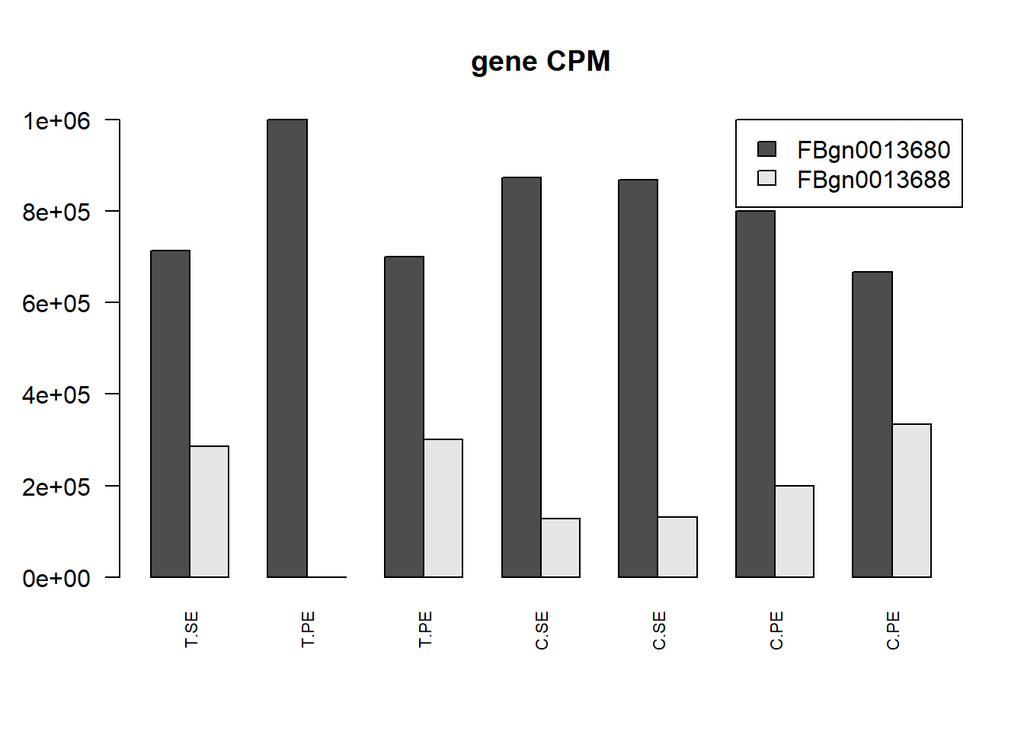

```r
sel_genes_names <- rownames(sel_genes[1:2, 0]) # pick two genes from top
bar_data <- edgeR::cpm(y$counts[sel_genes_names, ], normalized.lib.sizes = FALSE, log = FALSE) # cf. https://support.bioconductor.org/p/46779/
barplot(bar_data , las=2, cex.names=.7, names = conds, beside = TRUE, horiz = FALSE, main = 'gene CPM',
        legend.text = sel_genes_names, args.legend = list(x = 'topright'))
```

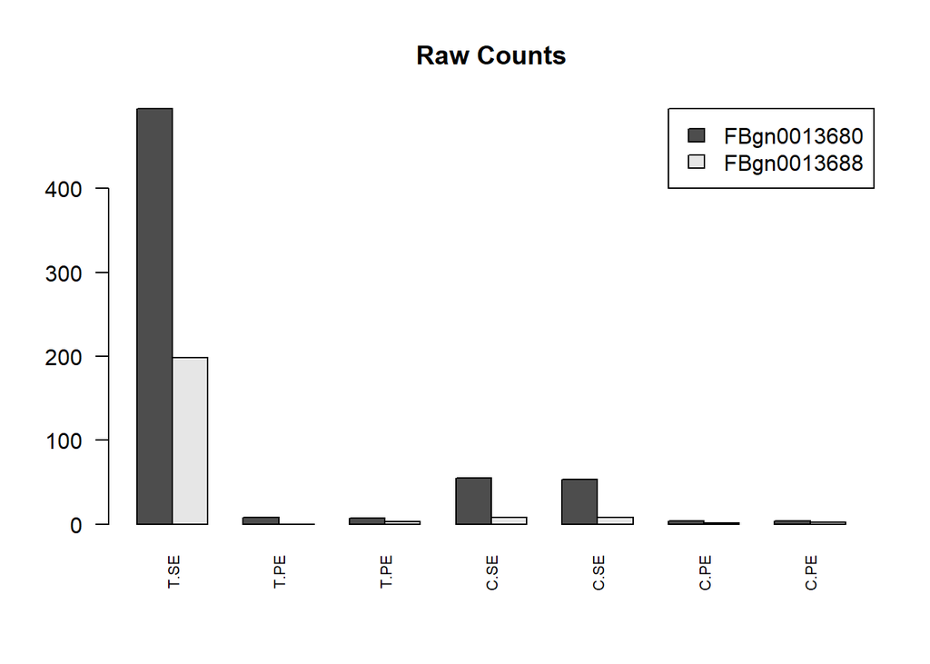

```r
bar_data <- counts[sel_genes_names, ]
barplot(bar_data , las=2, cex.names=.7, names = conds, beside = TRUE, horiz = FALSE, main = 'Raw Counts',
        legend.text = sel_genes_names, args.legend = list(x = 'topright'))
```

Next, we will explore “differential splicing”, using the same pasilla dataset (Note: this was used in the pasilla manuscript).

```r
library(pasilla)
sdir <- file.path(system.file(package="pasilla"),"extdata/")
anno <- file.path(sdir, "Dmel.BDGP5.25.62.DEXSeq.chr.gff")

samplesX = data.frame(cond = rep( c("trt","untrt"), c(3,4) ),
                      type = c("SE","PE","PE","SE","SE","PE","PE"),
                      countfile = dir(sdir,pattern="fb.txt"),
                      stringsAsFactors = TRUE)
samplesX
```

```
##    cond type        countfile
## 1   trt   SE   treated1fb.txt
## 2   trt   PE   treated2fb.txt
## 3   trt   PE   treated3fb.txt
## 4 untrt   SE untreated1fb.txt
## 5 untrt   SE untreated2fb.txt
## 6 untrt   PE untreated3fb.txt
## 7 untrt   PE untreated4fb.txt
```

```r
countFiles <- list.files(sdir, pattern="fb.txt")
```

#### Exercise 3. Fix the above code to run a standard DEXSeq analysis and plot one of the top differentially spliced genes – for example, see the plotDEXSeq() function.

#### Answer 3.:

Here is the edited code.

- One thing I struggle with is defining the design matrix, especially with interaction term. I wouldn’t know how to represent it in tems of an equation. *

```r
remove(dxd)
# Cannot use the same data as before, missing info on exons
# dxd <- DEXSeq::DEXSeqDataSet(countData = counts, sampleData = samples[, c('condition', 'libtype')])

dxd <- DEXSeq::DEXSeqDataSetFromHTSeq(
            countfiles=file.path( sdir, countFiles ),
            sampleData = samplesX,
            design = ~ exon + cond:exon + type:exon,
            flattenedfile = anno)
dxd <- DEXSeq::estimateSizeFactors( dxd , locfunc = genefilter::shorth) #locfunc = median
```

```
## Note: method with signature 'RangedSummarizedExperiment#DataFrame' chosen for function 'colData<-',
##  target signature 'DEXSeqDataSet#DataFrame'.
##  "SummarizedExperiment#DataFrame" would also be valid
```

```r
# Obtain dispersion estimates for negative binomial distributed data
dxd <- DEXSeq::estimateDispersions( dxd, fitType = 'parametric') #, formula = dxd@design)
```

```
## using supplied model matrix
```

```
## using supplied model matrix
```

```r
# Perform a likelihood ratio test for differential exon usage
dxd <- DEXSeq::testForDEU(dxd, reducedModel = ~ cond + exon)
```

```
## using supplied model matrix
```

```r
dxr <- DEXSeq::DEXSeqResults( dxd, independentFiltering = TRUE )
head(dxr)
```

```
##
## LRT p-value: full vs reduced
##
## DataFrame with 6 rows and 10 columns
##                      groupID   featureID exonBaseMean dispersion
##                  <character> <character>    <numeric>  <numeric>
## FBgn0000003:E001 FBgn0000003        E001    0.1551638         NA
## FBgn0000008:E001 FBgn0000008        E001    0.0000000         NA
## FBgn0000008:E002 FBgn0000008        E002    0.1909008  0.4857264
## FBgn0000008:E003 FBgn0000008        E003    0.5899405  0.1884503
## FBgn0000008:E004 FBgn0000008        E004    0.5190217  0.2088866
## FBgn0000008:E005 FBgn0000008        E005    1.3499071  0.1210562
##                        stat    pvalue      padj               genomicData
##                   <numeric> <numeric> <numeric>                 <GRanges>
## FBgn0000003:E001         NA        NA        NA   chr3R:2648220-2648518:+
## FBgn0000008:E001         NA        NA        NA chr2R:18024494-18024495:+
## FBgn0000008:E002 1.26568480 0.7372972        NA chr2R:18024496-18024531:+
## FBgn0000008:E003 0.61197555 0.8936855        NA chr2R:18024532-18024713:+
## FBgn0000008:E004 0.08725056 0.9933222        NA chr2R:18024938-18025504:+
## FBgn0000008:E005 1.82626994 0.6092351  0.755023 chr2R:18025505-18025756:+
##                  countData                         transcripts
##                   <matrix>                              <list>
## FBgn0000003:E001 0:0:1:...                         FBtr0081624
## FBgn0000008:E001 0:0:0:...                         FBtr0100521
## FBgn0000008:E002 0:0:0:...             FBtr0071763,FBtr0100521
## FBgn0000008:E003 0:1:0:...                         FBtr0071763
## FBgn0000008:E004 1:0:1:...                         FBtr0071764
## FBgn0000008:E005 4:1:1:... FBtr0071764,FBtr0071763,FBtr0100521
```

```r
# Remove nans .... why do we have them in the first place?
dxr_sub <- dxr[apply(dxr, 1, function(x) !any(is.na(x) )), ]

# Pick gene that shows low p-value for test on DEU
DEU_genes <- dxr_sub@listData$groupID[dxr_sub@listData$pvalue < 1e-50 & ! is.na(dxr_sub@listData$pvalue)]
DEU_gene <- DEU_genes[sample(length(DEU_genes), 1)]
DEU_gene
```

```
## [1] "FBgn0086056+FBgn0020910"
```

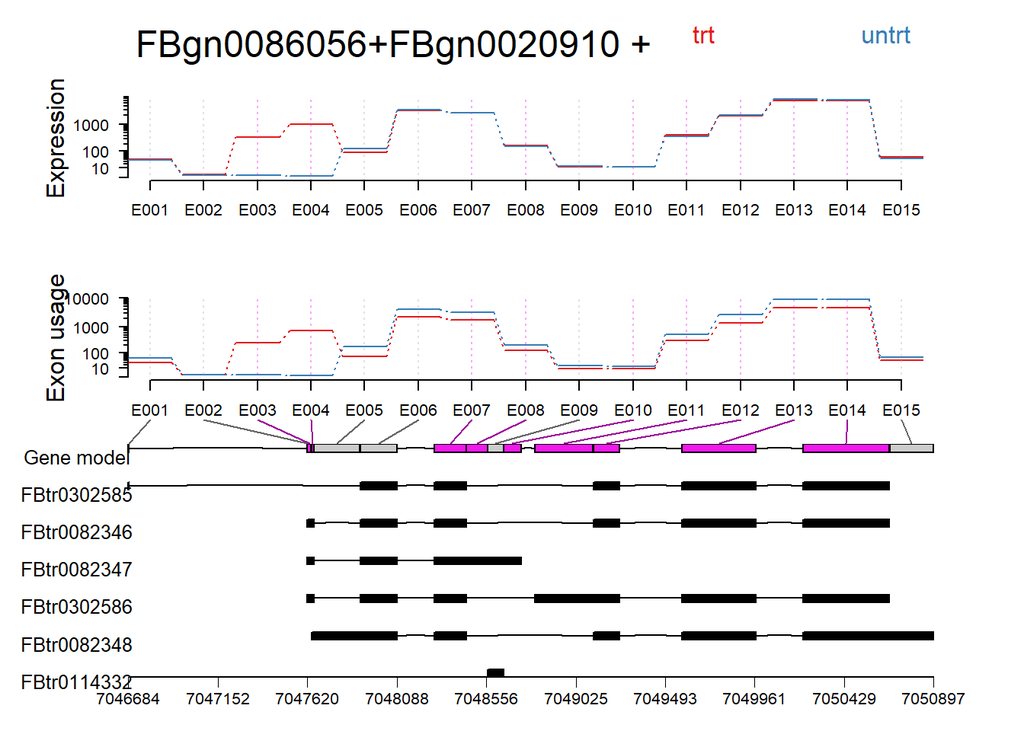

```r
par(oma=c(1,1,1,1))
# Plot
DEXSeq::plotDEXSeq(dxr, DEU_gene, fitExpToVar = 'cond', norCounts = FALSE, splicing = TRUE, displayTranscripts = TRUE, names = TRUE, legend = TRUE)
```

“Expression” is the expression strength of the gene, i.e., simply the average number of (normalized) reads that map to the sample in a given condition. “Exon usage” is an exon’s usage, compared to all the other exons of the same gene.